# Adstock Modeling: A Case Study

Daniel Petterson

An employee recruitment campaign was run across two different radio stations in Auckland. The advertisements included information regarding how to submit your CV online. It is of interest to determine if the campaigns had any effect on the number of views of the CV submission webpage and if so, which was more effective. The advertisement was run for the same length of time of each station over different yet overlapping time periods.

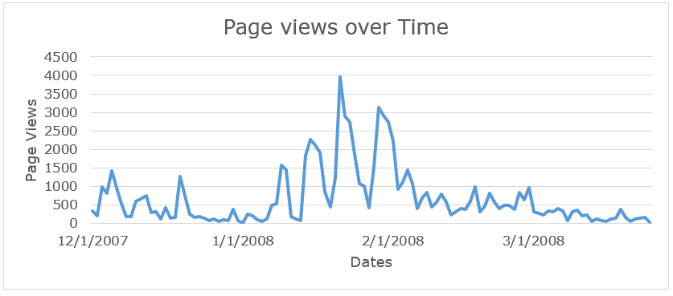

By plotting the response variable we can see some seasonal variation. The days of the week appear to influence the number of page views, with significantly lower page views on the weekend. There also appears to be a drop in number of page views in late December and early January which corresponds to the Christmas holiday period.  
The response variable, Page Views, does not satisfy the assumption for equality of variance so we will take the log form of that measure as our response variable for this analysis.

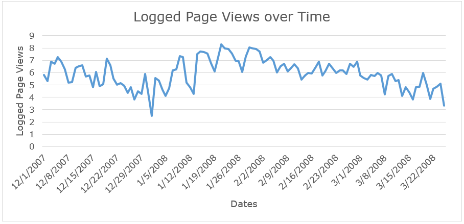

Dummy variables were created to control for potential seasonal effects mentioned above.

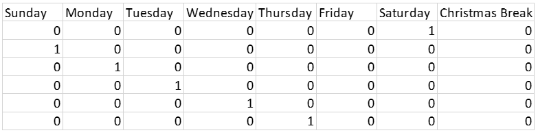

I then carried out a multiple linear regression of Logged Page Views by Day of Week, Christmas Break, Time and Adstock values for the advertising campaign by radio station. The decay rate for Adstock was modified for each radio station in order to maximise the ability of our model to explain the variability of the data. By using a decay rate of 30% for The Rock and 10% for Radio Live we are able to explain 63% of the variability in the relationship between Logged Page Views and time. This indicates that these decay values may be fairly representative of the rate of decay of Adstock for their respective stations. Changes in the decay rate for Radio Live resulted in very little change to the R-squared value relative to changes in the decay rate of The Rock.

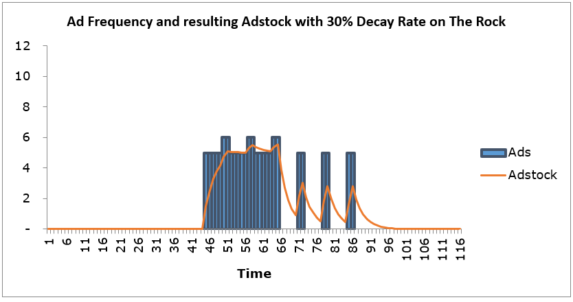

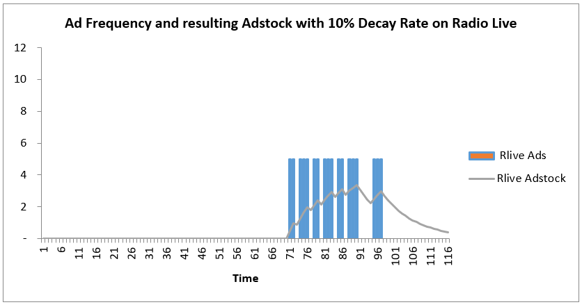

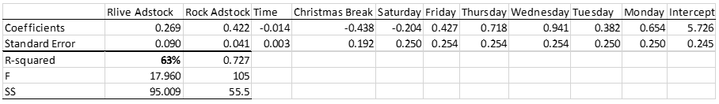

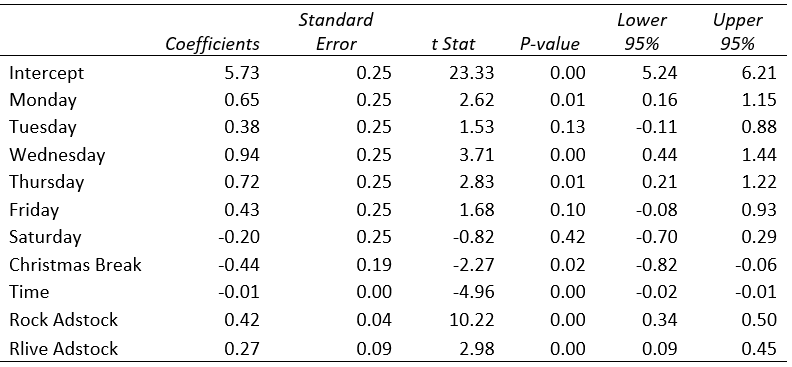

As the response variable is a natural log of its original value we will interpret each unit increase in an explanatory variable as a 100 times the coefficient percent change in the dependent variable Holding all else constant we estimate with 95% confidence that relative to Sunday: - Monday will see an increase in Page Views of between 15.9 and 115 percent - Wednesday will see an increase in Page Views of between 43.7 and 144.4 percent - Thursday will see an increase in Page Views of between 21.4 and 122 percent The number of page views seems to lessen over time with each day increase resulting in a decrease between 1 to 2 percent in page views. Holding all else constant we estimate with 95% confidence that an increase of one unit of Radio Live adstock will result in an increase of between 9% and 44.8% in the number of page views. Similarly a one unit increase in The Rock is estimated to increase page views by between 34 and 50.4 percent.

As the confidence intervals overlap considerably we cannot say that one is significantly better than the other at a 95% significance level but given the higher coefficient and lower variance, The Rock would seem to be the preferred choice if a similar recruitment campaign was to be run in future.It would also be advisable to run the ads on the weekdays, particularly on Monday, Wednesday and Thursday and to avoid running the campaign over the Christmas Break holidays.